# 2026-03-16-t-distribution

## Student's T-Distribution

*Student's T-distribution* (or simply T-distribution) is a probability distribution that is symmetric around zero and bell-shaped, like the standard normal distribution, but with heavier tails. The T-distribution $t_\nu$ (where $\nu$ are the degrees of freedom) approaches the standard normal distribution as $\nu\to\infty$. The name "Student" is a pseudonym for the English statistician William Sealy Gosset.

### Probability Density Function (PDF)

$f(t)=\frac{\Gamma(\frac{\nu+1}{2})}{\sqrt{\pi\nu}\Gamma(\frac{\nu}{2})}(1+\frac{t^2}{\nu})^{-(\nu+1)/2}$

Where:

- $\Gamma$ is the gamma function
- $\nu$ is the number of degrees of freedom

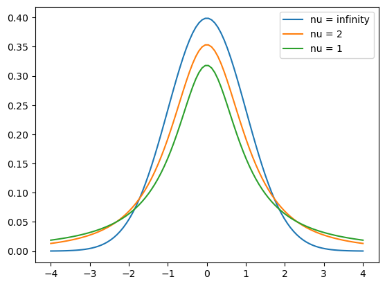

```python
import numpy as np
import matplotlib.pyplot as plt
from scipy.stats import t

x = np.linspace(-4, 4, 100)
z = t.pdf(x, df=np.inf)
t_2 = t.pdf(x, df=2)
t_1 = t.pdf(x, df=1)
plt.plot(x,z,label="nu = infinity")
plt.plot(x,t_2, label="nu = 2")
plt.plot(x,t_1, label="nu = 1")
plt.legend()
```

## T-score

Formula: $\large t_{n-1}=\frac{\bar{X}-\mu}{s/\sqrt{n}}$

The T-score quantifies how many estimated standard errors the sample mean ($\bar{X}$) is from the population mean ($\mu$). It plays a role in hypothesis testing, confidence intervals or linear regression analysis. The T-distribution provides a way to draw inference about population means based on small samples.

**Assumption**: The population is normally distributed.

**Use cases**: Use the T-distribution when samples are small and population variance is unknown.

## T-table

Similar to the Z-table for the standard normal distribution, there's also a T-table for student's T-distribution. In contrast to the Z-table where the fields are the outcomes from the cumulative distribution function, the T-table provides T-scores from different T-distributions, for different levels of significance. The table's indices indicate the degrees of freedom, the columns indicate common values for the significance level $\alpha$, and the fields are the corresponding T-scores.

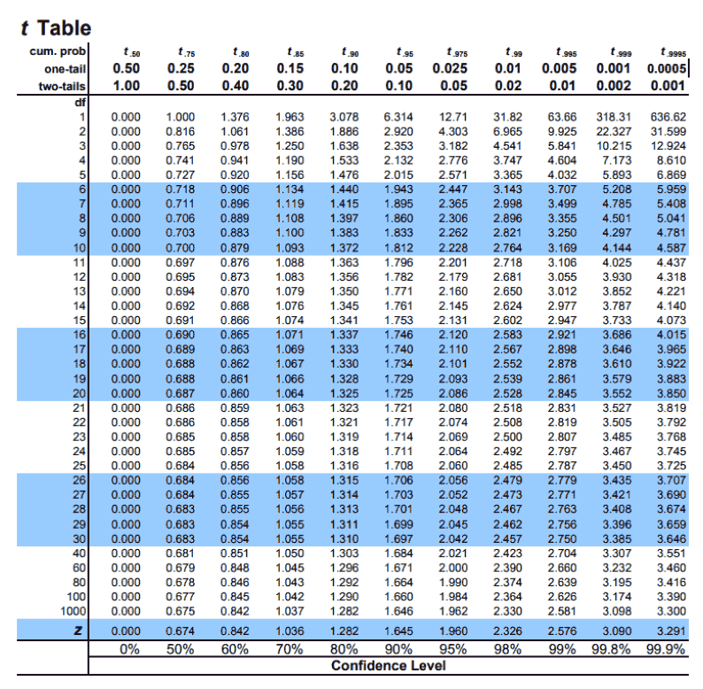

```python
fig, ax = plt.subplots(figsize=(10, 10))
ax.imshow(plt.imread("t-table.png"))
ax.set_axis_off()
```

Source: https://www.tdistributiontable.com

The corresponding T-score of a cumulative probability is given by the quantile function of the T-distribution.

$t=qt(p,df)$

- $p$ is the probability of observing a value lower or equal to $t$. $P(T \leq t)$
- $df$ are the degrees of freedom.

$F(t|\nu)=\int_{-\infty}^{t}f(x)dx=p$

- $F(t|\nu)$ is the cumulative distribution function of a T-distribution with $\nu$ degrees of freedom.
- $f(x)$ is the probability density function.

The quantile function is the inverse of the cumulative distribution function. In simple terms, the CDF takes a T-score as input and returns a probability. The quantile function takes a probability as input and returns a T-score.

$t=F^{-1}(p|\nu)$

#### In Python you can simply use the Scipy library to get the T-score:

```python
from scipy.stats import t

alpha = 0.05
n = 10
t.ppf(1-alpha, n-1)
```

```
np.float64(1.8331129326536335)
```

```python
import numpy as np
import pandas as pd

confidence = np.array([60, 65, 70, 75, 80, 85, 90, 95, 99])

# create the t-table
t_table = pd.DataFrame(data=[], index=np.arange(1, 31),
                       columns=((100 - confidence) / 100) / 2)
for idx in t_table.index:
    for col in t_table.columns:
        critical_t = t.ppf(1-col, idx)
        t_table.loc[idx, col] = np.round(critical_t, 6)
t_table.loc[len(t_table) + 1] = [f"{i}%" for i in confidence]

# highlight the t-score from the above example
def format_func(x):
    fmap = []
    for i,_ in x.items():
        if x.name == alpha and i == n-1:
            fmap.append("background-color: lightgreen; color: black")
        else:
            fmap.append(None)
    return fmap

t_table.style.apply(format_func)
```

|  | 0.200000 | 0.175000 | 0.150000 | 0.125000 | 0.100000 | 0.075000 | 0.050000 | 0.025000 | 0.005000 |
| --- | --- | --- | --- | --- | --- | --- | --- | --- | --- |
| 1 | 1.376382 | 1.631852 | 1.962611 | 2.414214 | 3.077684 | 4.165300 | 6.313752 | 12.706205 | 63.656741 |
| 2 | 1.060660 | 1.209629 | 1.386207 | 1.603567 | 1.885618 | 2.281931 | 2.919986 | 4.302653 | 9.924843 |
| 3 | 0.978472 | 1.104520 | 1.249778 | 1.422625 | 1.637744 | 1.924320 | 2.353363 | 3.182446 | 5.840909 |
| 4 | 0.940965 | 1.057299 | 1.189567 | 1.344398 | 1.533206 | 1.778192 | 2.131847 | 2.776445 | 4.604095 |
| 5 | 0.919544 | 1.030548 | 1.155767 | 1.300949 | 1.475884 | 1.699363 | 2.015048 | 2.570582 | 4.032143 |
| 6 | 0.905703 | 1.013349 | 1.134157 | 1.273349 | 1.439756 | 1.650173 | 1.943180 | 2.446912 | 3.707428 |
| 7 | 0.896030 | 1.001367 | 1.119159 | 1.254279 | 1.414924 | 1.616592 | 1.894579 | 2.364624 | 3.499483 |
| 8 | 0.888890 | 0.992545 | 1.108145 | 1.240318 | 1.396815 | 1.592221 | 1.859548 | 2.306004 | 3.355387 |
| 9 | 0.883404 | 0.985778 | 1.099716 | 1.229659 | 1.383029 | 1.573736 | 1.833113 | 2.262157 | 3.249836 |
| 10 | 0.879058 | 0.980425 | 1.093058 | 1.221255 | 1.372184 | 1.559236 | 1.812461 | 2.228139 | 3.169273 |
| 11 | 0.875530 | 0.976085 | 1.087666 | 1.214460 | 1.363430 | 1.547560 | 1.795885 | 2.200985 | 3.105807 |
| 12 | 0.872609 | 0.972495 | 1.083211 | 1.208853 | 1.356217 | 1.537956 | 1.782288 | 2.178813 | 3.054540 |
| 13 | 0.870152 | 0.969476 | 1.079469 | 1.204146 | 1.350171 | 1.529920 | 1.770933 | 2.160369 | 3.012276 |
| 14 | 0.868055 | 0.966903 | 1.076280 | 1.200140 | 1.345030 | 1.523095 | 1.761310 | 2.144787 | 2.976843 |
| 15 | 0.866245 | 0.964682 | 1.073531 | 1.196689 | 1.340606 | 1.517228 | 1.753050 | 2.131450 | 2.946713 |
| 16 | 0.864667 | 0.962748 | 1.071137 | 1.193685 | 1.336757 | 1.512130 | 1.745884 | 2.119905 | 2.920782 |
| 17 | 0.863279 | 0.961046 | 1.069033 | 1.191047 | 1.333379 | 1.507660 | 1.739607 | 2.109816 | 2.898231 |
| 18 | 0.862049 | 0.959539 | 1.067170 | 1.188711 | 1.330391 | 1.503708 | 1.734064 | 2.100922 | 2.878440 |
| 19 | 0.860951 | 0.958194 | 1.065507 | 1.186629 | 1.327728 | 1.500189 | 1.729133 | 2.093024 | 2.860935 |
| 20 | 0.859964 | 0.956987 | 1.064016 | 1.184761 | 1.325341 | 1.497036 | 1.724718 | 2.085963 | 2.845340 |
| 21 | 0.859074 | 0.955897 | 1.062670 | 1.183076 | 1.323188 | 1.494194 | 1.720743 | 2.079614 | 2.831360 |
| 22 | 0.858266 | 0.954908 | 1.061449 | 1.181549 | 1.321237 | 1.491620 | 1.717144 | 2.073873 | 2.818756 |
| 23 | 0.857530 | 0.954007 | 1.060337 | 1.180157 | 1.319460 | 1.489277 | 1.713872 | 2.068658 | 2.807336 |
| 24 | 0.856855 | 0.953182 | 1.059319 | 1.178884 | 1.317836 | 1.487136 | 1.710882 | 2.063899 | 2.796940 |
| 25 | 0.856236 | 0.952425 | 1.058384 | 1.177716 | 1.316345 | 1.485171 | 1.708141 | 2.059539 | 2.787436 |
| 26 | 0.855665 | 0.951727 | 1.057523 | 1.176639 | 1.314972 | 1.483363 | 1.705618 | 2.055529 | 2.778715 |
| 27 | 0.855137 | 0.951081 | 1.056727 | 1.175644 | 1.313703 | 1.481692 | 1.703288 | 2.051831 | 2.770683 |
| 28 | 0.854647 | 0.950482 | 1.055989 | 1.174722 | 1.312527 | 1.480143 | 1.701131 | 2.048407 | 2.763262 |
| 29 | 0.854192 | 0.949926 | 1.055302 | 1.173864 | 1.311434 | 1.478705 | 1.699127 | 2.045230 | 2.756386 |
| 30 | 0.853767 | 0.949407 | 1.054662 | 1.173065 | 1.310415 | 1.477365 | 1.697261 | 2.042272 | 2.749996 |
| 31 | 60% | 65% | 70% | 75% | 80% | 85% | 90% | 95% | 99% |

### Conclusion

Student's T-distribution is essential in inferential statistics, used to draw inference about population means. It is particularly useful when the sample size is small (<30) and population variance is unknown. T-scores are used as critical values in confidence intervals or as test statistics in a T-test.